# A2

Chuyue Wu & Menghong Han

## Step 1: library calls to load packages

```r
library(tidyverse)
library(leaflet)
library(WDI)
library(reshape2)
library(knitr)
library(plyr)
rm(list=ls())
gc()
```

```
##           used (Mb) gc trigger (Mb) limit (Mb) max used (Mb)
## Ncells  859382 45.9    1705812 91.2         NA  1177991 63.0
## Vcells 1459723 11.2    8388608 64.0      16384  2080524 15.9
```

## Step 2: Call package `WDI` to retrieve most updated figures available.

```r
birth <- "SP.DYN.CBRT.IN"
infmort <- "SP.DYN.IMRT.IN"
net <-"IT.NET.USER.ZS"
lifeexp <- "SP.DYN.LE00.IN"
forest <- "AG.LND.FRST.ZS"
mobile <- "IT.CEL.SETS.P2"
pop <- "SP.POP.TOTL"
tour <- "ST.INT.RCPT.CD"
import <- "TM.VAL.MRCH.XD.WD"
export <- "TX.VAL.MRCH.XD.WD"

# create a vector of the desired indicator series
indicators <- c(birth, infmort, net, lifeexp, forest,
                mobile, pop, tour, import, export)

countries <- WDI(country="all", indicator = indicators,
     start = 1998, end = 2018, extra = TRUE)

# rename columns for each of reference
countries <- rename(countries, c("SP.DYN.CBRT.IN" = "birth",
       "SP.DYN.IMRT.IN" = "infmort", "IT.NET.USER.ZS" = "net",
       "SP.DYN.LE00.IN" = "lifeexp", "AG.LND.FRST.ZS" = "forest",
       "IT.CEL.SETS.P2" = "mobile", "SP.POP.TOTL" = "pop",
       "ST.INT.RCPT.CD" = "tour",  "TM.VAL.MRCH.XD.WD" = "import",
       "TX.VAL.MRCH.XD.WD" = "export"))

# convert geocodes from factors into numerics

countries$lng <- as.numeric(as.character(countries$longitude))
countries$lat <- as.numeric(as.character(countries$latitude))

# Remove groupings, which have no geocodes
countries <- countries %>%
   filter(!is.na(lng))
```

## A Glimpse of the new dataframe

```r
glimpse(countries)
```

```
## Observations: 4,410
## Variables: 22
## $ iso2c     <chr> "AD", "AD", "AD", "AD", "AD", "AD", "AD", "AD", "AD", …
## $ country   <chr> "Andorra", "Andorra", "Andorra", "Andorra", "Andorra",…
## $ year      <int> 2018, 2007, 2004, 2005, 2017, 1998, 1999, 2000, 2006, …
## $ birth     <dbl> NA, 10.100, 10.900, 10.700, NA, 11.900, 12.600, 11.300…
## $ infmort   <dbl> 2.7, 4.5, 5.1, 4.9, 2.8, 6.4, 6.2, 5.9, 4.7, 5.5, 5.3,…
## $ net       <dbl> NA, 70.870000, 26.837954, 37.605766, 91.567467, 6.8862…
## $ lifeexp   <dbl> NA, NA, NA, NA, NA, NA, NA, NA, NA, NA, NA, NA, NA, NA…
## $ forest    <dbl> NA, 34.042553, 34.042553, 34.042553, NA, 34.042553, 34…
## $ mobile    <dbl> 107.28255, 76.80204, 76.55160, 81.85933, 104.33241, 22…
## $ pop       <dbl> 77006, 82684, 76244, 78867, 77001, 64142, 64370, 65390…
## $ tour      <dbl> NA, NA, NA, NA, NA, NA, NA, NA, NA, NA, NA, NA, NA, NA…
## $ import    <dbl> 136.50668, 190.30053, 174.09246, 178.06349, 146.27331,…
## $ export    <dbl> 268.35043, 332.78037, 271.81148, 314.89205, 264.92993,…
## $ iso3c     <fct> AND, AND, AND, AND, AND, AND, AND, AND, AND, AND, AND,…
## $ region    <fct> Europe & Central Asia, Europe & Central Asia, Europe &…
## $ capital   <fct> Andorra la Vella, Andorra la Vella, Andorra la Vella, …
## $ longitude <fct> 1.5218, 1.5218, 1.5218, 1.5218, 1.5218, 1.5218, 1.5218…
## $ latitude  <fct> 42.5075, 42.5075, 42.5075, 42.5075, 42.5075, 42.5075, …
## $ income    <fct> High income, High income, High income, High income, Hi…
## $ lending   <fct> Not classified, Not classified, Not classified, Not cl…
## $ lng       <dbl> 1.5218, 1.5218, 1.5218, 1.5218, 1.5218, 1.5218, 1.5218…
## $ lat       <dbl> 42.5075, 42.5075, 42.5075, 42.5075, 42.5075, 42.5075, …
```

## Plot from Phase 1

First, we extract necessary variables from “World Indicators.csv” and select the useful columns and filter countries. We also standardize data, which includes change characters in to numbers, and make numbers and variables more readable by changing units. Secondly, we melt variables to prepare for plotting. We melt three variables in to one column. Thirdly, we use ggplot to plot 5*3 faceted graph.

```r
library(ggplot2)
World.Indicators <- read.csv("~/Documents/Brandeis/Information Visualization/Assignment2/World Indicators.csv")
View(World.Indicators)
world_indicators_new <- World.Indicators[,c("Year", "Country", "Internet.Usage", "CO2.Emissions", "Health.Exp...GDP")]
world_indicators_new_country <- world_indicators_new[world_indicators_new$Country == "United States" | world_indicators_new$Country ==  "Brazil" | world_indicators_new$Country == "Russian Federation" | world_indicators_new$Country ==  "India" | world_indicators_new$Country == "China",]

world_indicators_new_country$Internet.Usage <- unlist(lapply(world_indicators_new_country$Internet.Usage, function(x)as.numeric(sub("%", "", x))))
world_indicators_new_country$CO2.Emissions <- as.numeric(world_indicators_new_country$CO2.Emissions/1000000)
world_indicators_new_country$Health.Exp...GDP<- unlist(lapply(world_indicators_new_country$Health.Exp...GDP, function(x)as.numeric(sub("%", "", x))))

world_indicators_new_country$Year <- as.numeric(substr(world_indicators_new_country$Year,6,9))
View(world_indicators_new_country)
world_indicators_new_country <- rename(world_indicators_new_country, c("Internet.Usage" = "Internet.Usage(%)", "CO2.Emissions" = "CO2.Emissions * 1e6 (ppm)", "Health.Exp...GDP" = "Health.Exp...GDP(%)"))
```

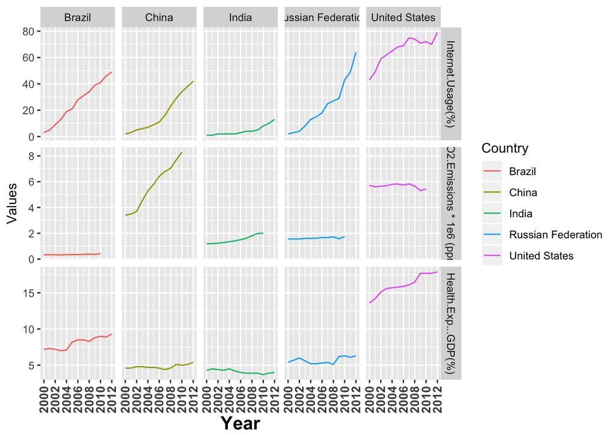

```r
mydata<-melt(world_indicators_new_country,id.vars=c("Year","Country"),variable.name="Threevariables",value.name="Values")

pic <- ggplot(mydata, aes(x = Year, y = Values)) +
       geom_line(aes(color = Country)) +
       facet_grid(Threevariables ~ Country, scales = "free_y") +
       scale_x_continuous(breaks = seq(2000, 2012, 2))+
       theme(axis.title.x = element_text(face="bold",  size=15),
             axis.text.x  = element_text(angle=90, vjust=0.5, size=10, face = "bold"))
pic
```

## World map showing a variable in 1998

We want to have a look at the life expectance in different countries in 1998 and 2008. First, we extract the data in 1998 in the countries table and exclude NA data. Then, because life expectance index is a numeric variable, we use colorNumeric function to create pal and use min and max function to check the maximum and minimum value of life expectance to set the range of pal. To draw the picture, we use leaflet package and addProviderTiles map. We use addCircle Markers function to draw circle at the location of each country’s capital as well as addLegend function to add ledegend at the bottom of the map. In the figure, red represents higher life expectancy while grenn represents lower life expectancy. We could tell from the figure that in 1998, the life expectancy in Europe is obivously higher in Africa, North America’s is higher than South America’s, and Asia’s average life expectancy is higher than Africa but lower than Europe and America

```r
View(countries)

countries_1998 <- countries %>% filter(countries$year == 1998&countries$lifeexp!="NA")
min(countries_1998$lifeexp)
```

```
## [1] 37.98
```

```r
max(countries_1998$lifeexp)
```

```
## [1] 80.50146
```

```r
pal <- colorNumeric(palette = "Spectral" , domain = c(30:90), reverse = TRUE)

countries_1998 %>%
    leaflet() %>%
    addProviderTiles("CartoDB") %>%
    addCircleMarkers(lng = countries_1998$lng, lat = countries_1998$lat, radius = 3, color = ~pal(lifeexp), label = ~country) %>%
    addLegend(title = 'Life expectance in 1998', opacity = 0.7, values = ~lifeexp, pal = pal, position = 'bottomleft')
```

[interactive chart not shown]

## World map showing the same variable recently

In this part, we change the selected year in the code above from 1998 to 2008. To make a clear comparation, we use the same range of pal in two figures. By comparing two figures, we found that in general, the average life expectancy has increased from 1998 to 2008, which is consistent with the actual situation, since people live a healthier life now than before and medical treatment is more advanced now. In addition, we could tell from the figure that some Asian developing countries such as India, China and Korea’s life expentancy increases in a faster speed from 1998 to 2008 than other countries. That’s because their noticeable GDP growth.

```r
countries_2008 <- countries %>% filter(countries$year == 2008&countries$lifeexp!="NA")
min(countries_2008$lifeexp)
```

```
## [1] 43.384
```

```r
max(countries_2008$lifeexp)
```

```
## [1] 82.68293
```

```r
pal <- colorNumeric(palette = "Spectral" , domain = c(30:90), reverse = TRUE)

countries_2008 %>%
    leaflet() %>%
    addProviderTiles("CartoDB") %>%
    addCircleMarkers(lng = countries_2008$lng, lat = countries_2008$lat, radius = 3, color = ~pal(lifeexp), label = ~country) %>%
    addLegend(title = 'Life expectance in 2008', opacity = 0.7, values = ~lifeexp, pal = pal, position = 'bottomleft')
```

[interactive chart not shown]